# FinalTutorial

Final Tutorial - Twitch Analytics by Josh Daly

Introduction:

One of my main hobbies is watching livestreamers on an app called Twitch. I felt that this project was a good way to connect the work we have done in class to a real life hobby of mine. Streaming is becoming a path to success for many as of recent years and I want to analyze the data and hopefully do some predictive modeling about the amount of followers certain streamers will get in the next year. There are many sites that allow for streaming including but not limited to Youtube, Facebook, and Twitch. These are mainly catered to english speaking sites as there are certain streaming sites that are more popular and almost unknown in different regions. China is one of these regions so I will specifically be honing in on the ones on Twitch.

Using a dataset from Kaggle I will be looking at the different categories for several of the top streamers on the platform and analyzing them. The goal of this project is to tidy the data and see which streamers are the most successful and which ones are likely to succeed in the future through following the data pipeline learned in class:

1. Data collection/curation + parsing (if necessary)
2. Data management/representation
3. Exploratory data analysis
4. Hypothesis testing
5. Communication of insights attained

STEP 1: Data Colletion/Curation + Parsing

Our data was retrieved from kaggle from this link https://www.kaggle.com/code/aleixcastellvi/twitch-streamers-analytics-using-python. To learn more about Twitch, check out this link https://www.digitaltrends.com/gaming/what-is-twitch/

I renamed the csv file "twitchdata-update.csv" and this is the dataset that will be used thoruhgout the project. Below are the imports that I am using for this project in order to analyze and portray the desired data. The data will be visualized and then used to predict the future of these streamers and their followers

```python
import pandas as pd
import numpy as np
import seaborn as sns
import matplotlib
from matplotlib import pyplot as plt
from sklearn.linear_model import LinearRegression
from sklearn.model_selection import train_test_split
from sklearn.preprocessing import StandardScaler
from plotly.offline import init_notebook_mode, iplot
init_notebook_mode(connected=True)
import plotly.graph_objs as go
import plotly.io as pio
import plotly.express as px
```

STEP 2: Data management/representation

After downloading the kaggle dataset, we used pandas read_csv to retrieve the data and the data is luckily already quite tidy so I did not need to do that much in this. There is not any missing data so this is quite simple. Below will just be reading the csv and then presenting it. This dataset includes the top 1000 streamers in the year 2020 and shows their watch time, stream time, peak viewers, average viewrs, follwoerse, follwoers gained, views gained, if they are partnered, if their conent in mature, and what language the stream is in.

```python
twitch_data = '/content/drive/MyDrive/Colab Notebooks/twitchdata-update.csv'
df = pd.read_csv(twitch_data)
df.head()
```

|  | Channel | Watch time(Minutes) | Stream time(minutes) | Peak viewers | Average viewers | Followers | Followers gained | Views gained | Partnered | Mature | Language |
| --- | --- | --- | --- | --- | --- | --- | --- | --- | --- | --- | --- |
| 0 | xQcOW | 6196161750 | 215250 | 222720 | 27716 | 3246298 | 1734810 | 93036735 | True | False | English |
| 1 | summit1g | 6091677300 | 211845 | 310998 | 25610 | 5310163 | 1370184 | 89705964 | True | False | English |
| 2 | Gaules | 5644590915 | 515280 | 387315 | 10976 | 1767635 | 1023779 | 102611607 | True | True | Portuguese |
| 3 | ESL_CSGO | 3970318140 | 517740 | 300575 | 7714 | 3944850 | 703986 | 106546942 | True | False | English |
| 4 | Tfue | 3671000070 | 123660 | 285644 | 29602 | 8938903 | 2068424 | 78998587 | True | False | English |

```python
df.isnull().sum() #checking for null values in the data
```

```
Channel                 0
Watch time(Minutes)     0
Stream time(minutes)    0
Peak viewers            0
Average viewers         0
Followers               0
Followers gained        0
Views gained            0
Partnered               0
Mature                  0
Language                0
dtype: int64
```

```python
df.dtypes #checking the type of each column
```

```
Channel                 object
Watch time(Minutes)      int64
Stream time(minutes)     int64
Peak viewers             int64
Average viewers          int64
Followers                int64
Followers gained         int64
Views gained             int64
Partnered                 bool
Mature                    bool
Language                object
dtype: object
```

STEP 3: Exploratory data analysis

The exploratory analysis is a crucial step in the data analysis process where we seek to understand the patterns, trends, and relationships in the data. During this step, we use various tools and techniques such as visualization, statistical tests, and data summaries to gain insights into the data and identify any potential issues or anomalies. The goal of exploratory analysis is to uncover hidden patterns and trends, formulate hypotheses, and identify areas of the data that require further investigation or analysis.

In the exploratory analysis stage, we typically start by getting a high-level overview of the data, such as its size, structure, and overall distribution. This can be done by looking at the data's summary statistics, such as the mean, median, and standard deviation, and by creating visualizations such as histograms, scatter plots, and box plots. These tools help us to understand the distribution and dispersion of the data, identify any outliers or anomalies, and get a sense of the overall shape of the data.

We can also use statistical tests and techniques such as t-tests, ANOVA, and regression analysis to explore relationships between variables and test hypotheses about the data. For example, we might use a t-test to compare the mean of two groups, or use regression analysis to understand the relationship between two variables and make predictions about one variable based on the other.

Overall, the exploratory analysis stage is an iterative process where we constantly refine our understanding of the data and formulate new hypotheses as we uncover new patterns and trends. It is an essential step in the data analysis process that helps us to understand the data and identify the most important factors and variables to focus on in our analysis.

Specifically for this data, there are many plots that we can do to showcase the differences in streamer success which will be seen below. Each category is explored separately with some being compared with one another to allow for easy analysis down the line

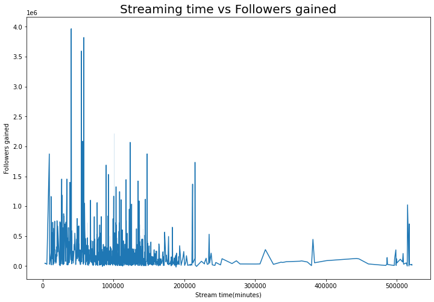

```python
plt.figure(figsize=(12,8)) #comparing streaming time vs followers gained
sns.lineplot(df['Stream time(minutes)'], df['Followers gained'], palette = "Set1")
plt.title('Streaming time vs Followers gained', fontsize = 20)
plt.show()
```

[output not shown]

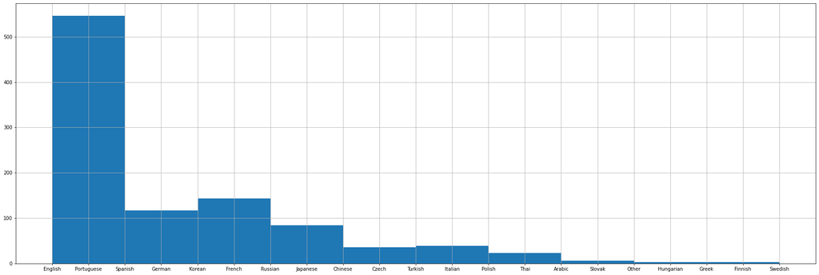

```python
languages = df['Language']#.value_counts()
languages.hist(figsize=(30,10))
```

[figure not shown]

```python
fig = plt.figure(figsize=(10,6))
sns.countplot(x="Mature", data=df)
plt.title("Mature vs Non-mature streamers")
plt.show()
```

```python
def top_streamers(language):

    filter = language.title()
    streamers_language = df.loc[df["Language"] == filter]
    streamers_language.reset_index(drop=True, inplace=True)

    channels = streamers_language["Channel"]
    total_watch_time = streamers_language["Watch time(Minutes)"]

    fig = plt.figure(figsize=(10, 6))
    plot = sns.barplot(x=channels[:10], y=total_watch_time[:10], palette="muted")
    plt.title("Top 10 most viewed channels in {language} in 2020")
    plt.xticks(rotation=45)
    plt.show()
```

[figure not shown]

```python
top_streamers("english")
```

[figure not shown]

```python
top_streamers("spanish")
```

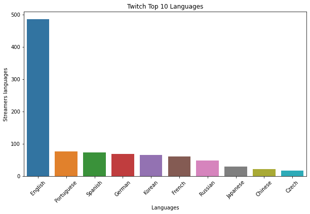

```python
languages_v = df["Language"].value_counts()
languages = df["Language"].unique()
fig = plt.figure(figsize=(10, 6))
languages_sns = sns.barplot(x=languages[:10], y=languages_v[:10])
languages_sns.set(xlabel="Languages", ylabel="Streamers languages")
plt.title("Twitch Top 10 Languages")
plt.xticks(rotation=45)
plt.show()
```

```python
def highest_streaming_time(x):
    return df.loc[df['Stream time(minutes)']==x]
def highest_watch_time(x):
    return df.loc[df['Watch time(Minutes)']==x]
def highest_avg_viewers(x):
    return df.loc[df['Average viewers']==x]
def highest_followers(x):
    return df.loc[df['Followers']==x]
def highest_followers_gained(x):
    return df.loc[df['Followers gained']==x]
def highest_views_gained(x):
    return df.loc[df['Views gained']==x]
highest_streaming_time(df['Stream time(minutes)'].max())
```

|  | Channel | Watch time(Minutes) | Stream time(minutes) | Peak viewers | Average viewers | Followers | Followers gained | Views gained | Partnered | Mature | Language |
| --- | --- | --- | --- | --- | --- | --- | --- | --- | --- | --- | --- |
| 392 | RiffTrax | 293583075 | 521445 | 24765 | 562 | 79099 | 17200 | 3313465 | True | False | English |

```python
highest_watch_time(df['Watch time(Minutes)'].max())
```

|  | Channel | Watch time(Minutes) | Stream time(minutes) | Peak viewers | Average viewers | Followers | Followers gained | Views gained | Partnered | Mature | Language |
| --- | --- | --- | --- | --- | --- | --- | --- | --- | --- | --- | --- |
| 0 | xQcOW | 6196161750 | 215250 | 222720 | 27716 | 3246298 | 1734810 | 93036735 | True | False | English |

```python
highest_avg_viewers(df['Average viewers'].max())
```

|  | Channel | Watch time(Minutes) | Stream time(minutes) | Peak viewers | Average viewers | Followers | Followers gained | Views gained | Partnered | Mature | Language |
| --- | --- | --- | --- | --- | --- | --- | --- | --- | --- | --- | --- |
| 81 | dota2ti | 1017577605 | 6315 | 483530 | 147643 | 663297 | 121422 | 16228039 | True | False | English |

```python
highest_followers(df['Followers'].max())
```

|  | Channel | Watch time(Minutes) | Stream time(minutes) | Peak viewers | Average viewers | Followers | Followers gained | Views gained | Partnered | Mature | Language |
| --- | --- | --- | --- | --- | --- | --- | --- | --- | --- | --- | --- |
| 4 | Tfue | 3671000070 | 123660 | 285644 | 29602 | 8938903 | 2068424 | 78998587 | True | False | English |

```python
highest_views_gained(df['Followers gained'].max())
```

[output not shown]

```python
highest_views_gained(df['Views gained'].max())
```

|  | Channel | Watch time(Minutes) | Stream time(minutes) | Peak viewers | Average viewers | Followers | Followers gained | Views gained | Partnered | Mature | Language |
| --- | --- | --- | --- | --- | --- | --- | --- | --- | --- | --- | --- |
| 7 | Fextralife | 3301867485 | 147885 | 68795 | 18985 | 508816 | 425468 | 670137548 | True | False | English |

[figure not shown]

```python
plt.figure(figsize = (20,7))
df['Average viewers'].head(50).plot.bar(color = 'blue')
plt.title('Comparing the average viewers of Top 50 Streamers')
plt.xlabel('Streamers')
plt.ylabel('Count')
plt.show()
```

[figure not shown]

```python
plt.figure(figsize = (20,7))
df['Stream time(minutes)'].head(50).plot.bar(color = 'red')
plt.title('Comparing stream times (in minutes)')
plt.xlabel('Streamers')
plt.ylabel('Count')
plt.show()
```

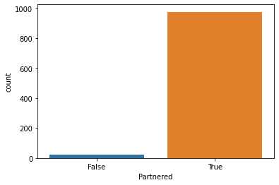

```python
sns.countplot(x='Partnered',data = df) #checking how many streamers are twitch partnered
```

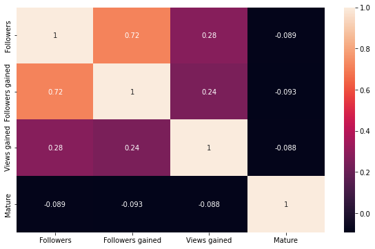

```python
fig = plt.figure(figsize=(10, 6))
heatmap = sns.heatmap(df[["Channel", "Followers", "Followers gained", "Views gained", "Mature", "Language"]].corr(), annot=True)
plt.show()
```

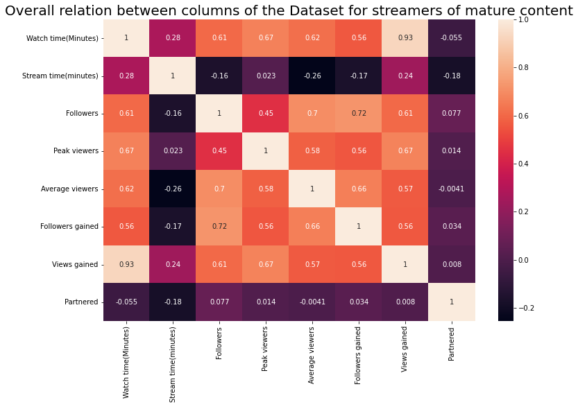

```python
mature = df.loc[df['Mature'] == True]
plt.figure(figsize=(12,8))
sns.heatmap(mature[['Channel', 'Watch time(Minutes)', 'Stream time(minutes)', 'Followers','Peak viewers','Average viewers','Followers gained','Views gained','Partnered','Language']].corr(), annot = True)
plt.title('Overall relation between columns of the Dataset for streamers of mature content', fontsize = 20)
plt.show()
```

STEP 4: Hypothesis testing

My hypothesis is: Streamers who have higher average viewer counts and more followers will be more successful on Twitch, as indicated by their watch time and streaming time.

```python
features = df[['Watch time(Minutes)','Stream time(minutes)','Peak viewers','Average viewers','Followers','Views gained']]
target = df['Followers gained']
X_train,X_test,y_train,y_test = train_test_split(features,target,test_size = 0.2,random_state = 101)
scaler = StandardScaler()
scaler.fit(X_train)
X_train = scaler.transform(X_train)
X_test = scaler.transform(X_test)
model  = LinearRegression()
model.fit(X_train,y_train)
predictions = model.predict(X_test)
from sklearn.metrics import r2_score, mean_squared_error
print('r2 score:'+str(r2_score(y_test, predictions)))
print('RMSE :'+str(np.sqrt(mean_squared_error(y_test, predictions))))
```

```
r2 score:0.5366031433627445
RMSE :202315.23271199077
```

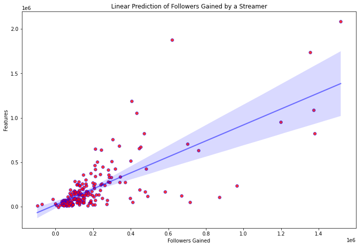

```python
plt.figure(figsize=(12,8))
sns.regplot(predictions,y_test,scatter_kws={'color':'red','edgecolor':'blue','linewidth':'0.7'},line_kws={'color':'blue','alpha':0.5})
plt.xlabel('Followers Gained')
plt.ylabel('Features')
plt.title("Linear Prediction of Followers Gained by a Streamer")
plt.show()
```

STEP 5: Conclusion

Overall, this project has provided valuable insights into the world of Twitch streaming and will be useful for streamers and other stakeholders looking to understand the trends and patterns in the data. While there is always room for further analysis and exploration, the findings from this project offer a solid foundation for future research in this area. So, it can be a great help for streamers and other stakeholders to plan their strategies accordingly and make informed decisions based on this information.

```python
!jupyter nbconvert --to html /content/drive/MyDrive/ColabNotebooks/FinalTutorial.ipynb
```

[output not shown]

[output cut: 107 more lines]

[output not shown]